# TSIRO Baseline Data Analysis

Stella Banino

2022-12-22

## Importing the data

```r
setwd("C:/Users/scban/Documents/UVA/TSIROBaselineDataAnalysis")
tsiro_raw_data <- read_dta("TSIRO_baseline_public_gender.dta")
view(tsiro_raw_data)
```

## Breaking down and cleaning the dataset

Let’s start by dividing the dataset into each separate module and making the sex columns easier to understand.

```r
tsiro_fm_data <- tsiro_raw_data%>%
  mutate_at(c("head_sex", "spouse_sex", "mod_b_respondent_sex", "mod_c_respondent_sex", "mod_d_respondent_sex", "mod_e_respondent_sex", "mod_f_respondent_sex", "mod_i_respondent_sex", "mod_h_respondent_sex", "mod_g_respondent_sex", "mod_c_wdd_respondent_sex"), as.character)%>%
  mutate(across(c("head_sex", "spouse_sex", "mod_b_respondent_sex", "mod_c_respondent_sex", "mod_d_respondent_sex", "mod_e_respondent_sex", "mod_f_respondent_sex", "mod_i_respondent_sex", "mod_h_respondent_sex", "mod_g_respondent_sex", "mod_c_wdd_respondent_sex"), str_replace, "1", "M"))%>%
  mutate(across(c("head_sex", "spouse_sex", "mod_b_respondent_sex", "mod_c_respondent_sex", "mod_d_respondent_sex", "mod_e_respondent_sex", "mod_f_respondent_sex", "mod_i_respondent_sex", "mod_h_respondent_sex", "mod_g_respondent_sex", "mod_c_wdd_respondent_sex"), str_replace, "2", "F"))
#glimpse(tsiro_raw_data)


roster <- select(tsiro_fm_data, hhid_deid, head_sex,spouse_sex,region,hhsize:read_head, fokontany_deid)
agriculture <- select(tsiro_fm_data, hhid_deid, mod_d_respondent_sex, plots:nrm_pract_y)
credit <- select(tsiro_fm_data, hhid_deid, mod_e_respondent_sex, loan_ngo:assist_inputs)
resources <- select(tsiro_fm_data, hhid_deid, mod_f_respondent_sex, trees:threats_other_EN)
energy <- select(tsiro_fm_data, hhid_deid, mod_g_respondent_sex, fuel_sources:fuel_dist1_3)
poverty <- select(tsiro_fm_data, hhid_deid, mod_i_respondent_sex, tv:detergent, birth, children_5_18)
foodsec <- select(tsiro_fm_data, hhid_deid, mod_c_respondent_sex, mod_c_wdd_respondent_sex, fies_enough:mddw)
empower <- select(tsiro_fm_data, hhid_deid, head_sex,spouse_sex, mod_h_respondent_sex, partner:alone)

# view(roster)
# view(agriculture)
# view(credit)
# view(resources)
# view(energy)
# view(poverty)
# view(foodsec)
# view(empower)
```

#### Transforming the resources section

One of the priority indicators is a sum of respondent’s scores on how important they believe each resource is, so I created this as a variable. I also renamed the threats to more memorable variable names. I was curious whether households were planting trees with the intention of cutting them down or with the intention of leaving them standing for their ecosystem services. Both would be better than not planting trees, but the latter could have a bigger impact on ecosystem health. I created variables designating this.

```r
# glimpse(resources)
resources_views <- resources%>%
  rename(protect = protect_label)%>%
  mutate(across(starts_with("protect_"), ~ .x - 3))
# formatting so operations are easier

resources_views <- resources_views %>%
  mutate(protect_avg = rowMeans(select(resources_views, starts_with("protect_")), na.rm = TRUE), .after = protect_med)%>%
  mutate(protect_sum = protect_avg*8)
# Calculating priority indicator "Average score measuring the perceived
# importance of protecting nature and the environment".
# Asks about the importance of 8 ecosystem services relevant to this population.

resources_views <- resources_views %>%
  rename("threats_illegal_logging" = "threats_big_a",
         "threats_slash_burn" = "threats_big_b",
         "threats_poaching" = "threats_big_c",
         "threats_wildlife_trafficking" = "threats_big_d",
         "threats_seine_fishing" = "threats_big_e",
         "threats_fishing_other" = "threats_big_f",
         "threats_climate_change" = "threats_big_g",
         "threats_farming" = "threats_big_h",
         "threats_resource_use" = "threats_big_i")

resources_trees <- resources_views%>%
  mutate(trees_why_perm = ifelse((trees_why_a == 1 |
                                    trees_why_e == 1 |
                                    trees_why_f == 1 |
                                    trees_why_i == 1 |
                                    trees_why_j == 1), 1, 0),
         trees_why_cut = ifelse((trees_why_b == 1 |
                                   trees_why_c == 1 |
                                   trees_why_d == 1 |
                                   trees_why_g == 1 |
                                   trees_why_h == 1 |
                                   trees_why_b == 1), 1, 0), .after = trees_other_EN)
```

#### Calculating FIES and PPI

PPI is the Poverty Probability Index. This index was developed by INRM for this data set. It shows the probability each household is in poverty, based on a model developed with regression on recent Malagasy data.

```r
# view(foodsec)

foodsec_fies <- foodsec%>%
  mutate(fies_unw_avg = rowMeans(select(foodsec, starts_with("fies_")), na.rm = TRUE), .after = fies_day)

# view(poverty)

poverty_ppi <- poverty%>%
  mutate(soap_water = as.numeric(water == 1 & (detergent == 1 | detergent == 2)),
         soap_4k = as.numeric(soap > 4000))%>%
  mutate(ppi = (77)*1 + (-13)*food_1 + (-13)*tv + (-12)*food_2 + (-7)*food_3
                    + (-5)*clothes_1 + (-4)*linen_2 + (4)*food_5 + (-4)*clothes_2
                    + (4)*birth + (-4)*food_4 + (-3)*clothes_3
                    + (-3)*soap_water + (-3)*shoes + (2)*children_5_18 + (-2)*linen_1
                    + (-1)*soap_4k + (-1)*roofmat)

summarise(poverty_ppi, across(everything(), ~ sum(is.na(.x))))
```

```
## # A tibble: 1 x 30
##   hhid_deid mod_i_respondent_sex    tv  food food_1 food_2 food_3 food_4 food_5
##       <int>                <int> <int> <int>  <int>  <int>  <int>  <int>  <int>
## 1         0                    0     0     0      0      0      0      0      0
## # ... with 21 more variables: food_6 <int>, clothes <int>, clothes_1 <int>,
## #   clothes_2 <int>, clothes_3 <int>, clothes_6 <int>, soap <int>, shoes <int>,
## #   roofmat <int>, linen <int>, linen_1 <int>, linen_2 <int>, linen_6 <int>,
## #   wash <int>, water <int>, detergent <int>, birth <int>, children_5_18 <int>,
## #   soap_water <int>, soap_4k <int>, ppi <int>
```

## Creating narrow dataset

Once I explored each section, I chose a few variables from each to focus on for further analysis. I merged these together here.

```r
roster_merge <- roster%>%
  select(hhid_deid, head_sex, spouse_sex, gender_hh_type:fokontany_deid)

agriculture_merge <- agriculture%>%
  select(hhid_deid, nrm_pract_a:nrm_pract_y)

credit_merge <- credit%>%
  select(hhid_deid, loan_ngo, loan_informal, loan_formal, loan_friend, loan_group, loan_sav, starts_with("member_"))

resources_merge <- resources_trees

energy_merge <- energy%>%
  select(hhid_deid, starts_with("fuel_sources"), starts_with("fuel_men"), starts_with("fuel_women"))

poverty_merge <- poverty_ppi%>%
  select(hhid_deid, ppi)

foodsec_merge <- foodsec_fies%>%
  select(hhid_deid, fies_enough:fies_unw_avg, CSI, birth, mddw)

final <- reduce(list(roster_merge, agriculture_merge, credit_merge, resources_merge, energy_merge, poverty_merge, foodsec_merge), full_join, by = "hhid_deid")%>%
  # how many natural resource management practices is this household using?
  mutate(nrm_pract_sum = rowSums(select(agriculture_merge, nrm_pract_a:nrm_pract_y)), .after = nrm_pract_g)%>%
  # how many hours are men vs. women spending collecting fuel
  mutate(across(fuel_men_1:fuel_women_6), replace_na(0))%>%
  mutate(fuel_men_hours = rowSums(select(energy_merge, fuel_men_1:fuel_men_6), na.rm = TRUE), .after= fuel_women_6)%>%
  mutate(fuel_women_hours = rowSums(select(energy_merge, fuel_women_1:fuel_women_6), na.rm = TRUE), .after = fuel_men_hours)
```

## Analysis

#### Creating USAID ggplot theme

Developed using USAID branding guidelines.

```r
theme_usaid <- function(){
    font <- "Gill Sans MT"
    theme_classic() %+replace%
    theme(
      #grid elements
      panel.grid.major = element_line(),
      plot.margin = margin(1, 1, 1, 1, "cm"),
      aspect.ratio = .9,
      #text elements
      plot.title = element_text(family = font, size = 16, hjust = 0, vjust = 1),
      axis.title = element_text(family = font, size = 12),
      axis.text = element_text(family = font, size = 12),
      axis.text.x = element_text(margin=margin(5, b = 10)),
      legend.text=element_text(family = font, size = 12)
    )
}
```

#### Initial exploration of correlations with environmental beliefs

The gender perspective didn’t make it into the final article, but the focus on environmental beliefs did. Later in this code chunk, I began exploring correlations with environmental experience.

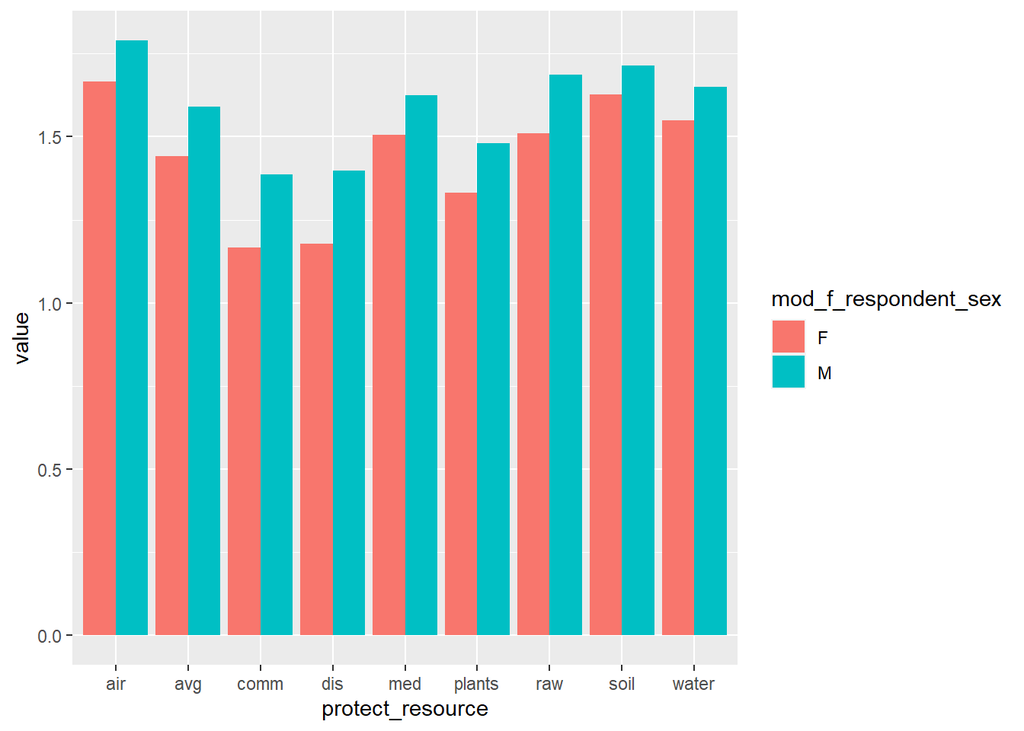

```r
# I started with an exploration of the views on importance of different environmental resources.

final%>%
  group_by(mod_f_respondent_sex)%>%
  summarise(across(protect_water:protect_avg, ~ (mean(.x, na.rm = TRUE))))%>%
  pivot_longer(protect_water:protect_avg, names_to = "protect_resource", names_prefix = "protect_")%>%
  ggplot(aes(protect_resource, value, group = mod_f_respondent_sex))+
  geom_col(aes(fill = mod_f_respondent_sex), position = "dodge")
```

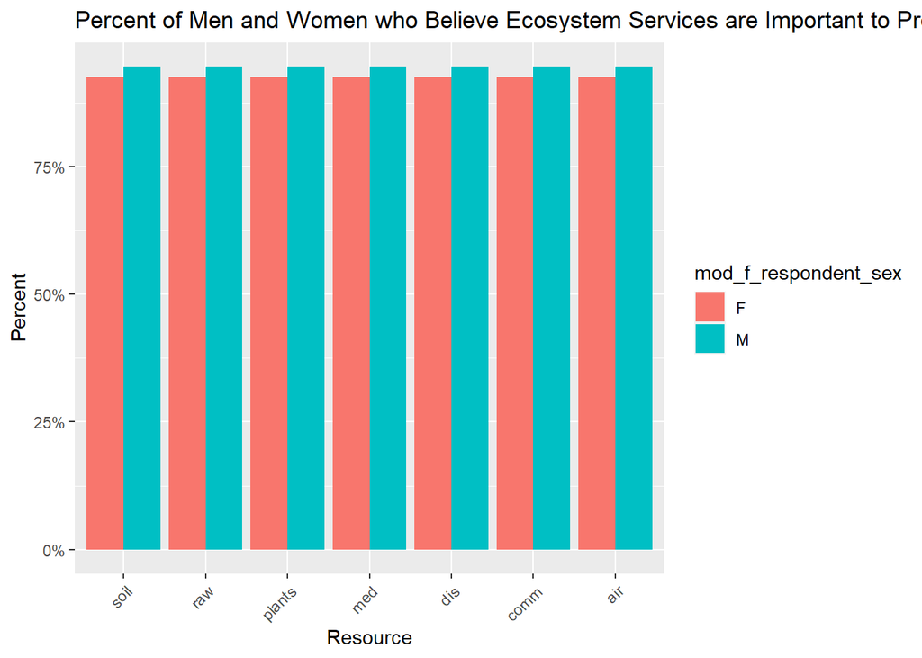

```r
# this looks at average scores on a five-point scale.  What about just a blanket
# do you think this resource is important or not?

final%>%
  mutate(yn_protect_water = ifelse(protect_water > 0, 1, 0),
         yn_protect_air = ifelse(protect_water > 0, 1, 0),
         yn_protect_soil = ifelse(protect_water > 0, 1, 0),
         yn_protect_comm = ifelse(protect_water > 0, 1, 0),
         yn_protect_raw = ifelse(protect_water > 0, 1, 0),
         yn_protect_plants = ifelse(protect_water > 0, 1, 0),
         yn_protect_dis = ifelse(protect_water > 0, 1, 0),
         yn_protect_med = ifelse(protect_water > 0, 1, 0),
         .after = protect_avg)%>%
  group_by(mod_f_respondent_sex)%>%
  summarise(across(yn_protect_water:yn_protect_med, ~ (mean(.x, na.rm = TRUE))))%>%
  pivot_longer(yn_protect_air:yn_protect_med, names_to = "yn_protect_resource", names_prefix = "yn_protect_")%>%
  ggplot(aes(fct_rev(fct_reorder(yn_protect_resource, value)), value, group = mod_f_respondent_sex))+
  geom_col(aes(fill = mod_f_respondent_sex), position = "dodge")+
  scale_y_continuous(labels = scales::percent)+
  guides(x = guide_axis(angle = 45))+
  labs(title = "Percent of Men and Women who Believe Ecosystem Services are Important to Protect...",
       x = "Resource",
       y = "Percent")
```